# Stats 369 Assignment3

Yongqi Liang

27/09/2021

```r
load("spam.rda")
spam <- wordmatrix # copy data frame
# remove "w_" for all the column names
colname <- sapply(colnames(spam), function(name){name = substr(name, 3, nchar(name))})
colnames(spam) <- colname

spam.df <- as_tibble(spam) %>% add_column(is_spam = as.factor(df$is_spam), .before = 1)
```

## Task1

1. Use rpart to fit and prune a tree predicting spam/non-spam from the common word counts in the wordmatrix matrix. Produce a confusion matrix and report its accuracy. Plot the fitted tree (without all the text labels) and comment on its shape.

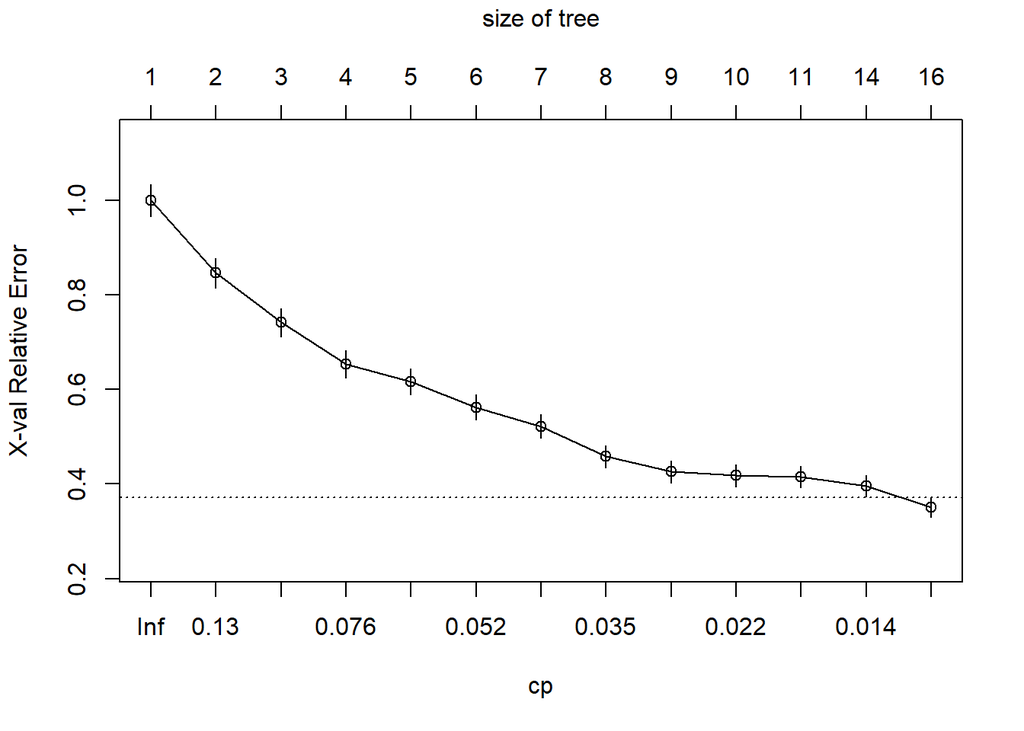

```r
set.seed(107)
tree1 <- rpart(is_spam~., data = spam.df)
prune_tree1 <- tree1 %>% prune(cp = 0.01)
plotcp(prune_tree1)
```

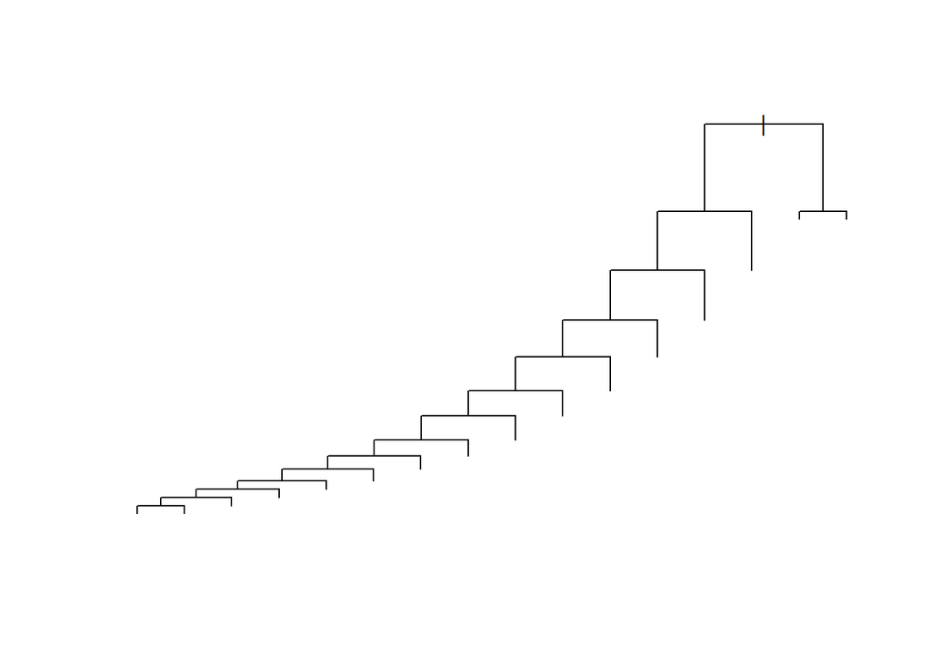

```r
plot(prune_tree1)
```

```r
predict1 <-  predict(prune_tree1, type = "class") # Sufficient to get fitted values out
# Can also do predict(autism.tree1, autism.subset, type = "class")
confMatrix1 <-  table(Actual = spam.df$is_spam, Predicted = predict1)
confMatrix1
```

```
##        Predicted
## Actual  FALSE TRUE
##   FALSE  4785   42
##   TRUE    181  566
```

```r
# accuracy
sum(diag(confMatrix1)) / nrow(spam.df)
```

```
## [1] 0.9599928
```

The accuracy of this tree is about 0.96. The left side of the tree has so many branches and leaf nodes, but the right of the tree only has two nodes. It may be due to there is one feature that can easily classify the message.

## Task 2

```r
y_n <- spam.df %>%
  group_by(is_spam) %>%
  summarise(across(where(is.integer), sum)) %>%
  select(-is_spam)
y_i = t(y_n[2,]) # counts of spam messages containing each words
n_i = t(y_n[1,]) # counts of non-spam messages containing each words
e_i <- log(y_i+1) - log(n_i+1) # overall evidence provided by having each word
```

```r
df <- data.frame(matrix(vector(), 0, 2)) # create an empty data frame to store the label and overall evidence for this message
names(df) <- c("label","value") # rename the columns

for (i in 1:nrow(spam.df)) { # for each piece of message
  label <- spam.df[i,][1,1] # the label
  row1 <- spam.df[i,-1] # all words with theirs value
  row_val <- t(row1) # transpose our data frame
  words <- row1[,which(row_val > 0)] # find the words with value more than 0
  colname <- colnames(words) # get these words
  e <- e_i[colname,] # get the overall evidence of these words
  occurance <- t(words) # transpose our data frame
  summ <- sum(e * occurance) # sums up the e_i for every common word in the message
  de <- data.frame(label,summ) # create a new data frame to store these information
  names(de) <- c("label","value")
  df <- rbind(df, de) # add to df
}
head(df)
```

```
##   label     value
## 1 FALSE -38.42126
## 2 FALSE -22.59465
## 3  TRUE  11.40284
## 4 FALSE -36.83491
## 5 FALSE -34.69777
## 6  TRUE -39.33583
```

```r
df_ordered <- df %>% arrange(desc(value)) # reorder the messages by their values
head(df_ordered)
```

```
##   label    value
## 1  TRUE 26.93491
## 2  TRUE 25.02035
## 3  TRUE 24.60870
## 4  TRUE 24.60870
## 5  TRUE 24.60870
## 6  TRUE 24.41258
```

```r
df_ordered %>% group_by(label) %>% summarise("count" = n())
```

```
## # A tibble: 2 x 2
##   label count
##   <fct> <int>
## 1 FALSE  4827
## 2 TRUE    747
```

```r
# the proportion of spam observed
obs_spam <- 747 / 5574
obs_spam
```

```
## [1] 0.1340151
```

The proportion of spam observed is 13.4%. So the threshold is 13.4%. Hence, we predict the first 13.4% are spam.

```r
threshold_i <- nrow(df_ordered)*obs_spam # the index of the last spam message we predicted
cutoff <- df_ordered[threshold_i,2] # the cut off

predict_spam <- df_ordered[1:threshold_i,]
predict_notspam <- df_ordered[-(1:threshold_i),]

correst_notspam <- sum(as.numeric(predict_notspam$label == FALSE)) # the number of messages have the correct label
correct_spam <- sum(as.numeric(predict_spam$label == TRUE)) # the number of messages have the correct label

accuracy <- (correst_notspam + correct_spam) / 5574
accuracy
```

```
## [1] 0.8805167
```

The accuracy of our classifier is 88%

```r
predict2 <- c(rep("TRUE", 747), rep("FALSE", 5574-747))
# confusion matrix
confMatrix2 <-  table(Actual = df_ordered$label, Predicted = predict2)
confMatrix2
```

```
##        Predicted
## Actual  FALSE TRUE
##   FALSE  4494  333
##   TRUE    333  414
```

## Task 3

Our data set is mostly from a subset of 3,375 randomly chosen ham messages from about 10,000 legitimate messages collected for research at the Department of Computer Science at the National University of Singapore. The messages mostly from students attending the university. So this data set might not be representative. Since in our real life, people will receive messages from different fields and during different stages of their life(different age groups), which means they would receive different spam messages. However, our messages are mostly for university students. The content of the message can be different in other situations. So our classifier may not do a good job classifying the spam data from people in other age groups or other areas (students not attending university).

Furthermore, there will be more spam messages in the real world because most people without reporting the spam message received in our data set. If we apply our classifier to the real-life data set, the result may be underestimated. In addition, our classifier was trained by the same data set as the test data set, so it may be overfitting on our collected data.

So the spam/non-spam accuracy is likely to be higher with this data set than in real life.